# COVID-19 5-day forecast

Adam Clark

Dezember 11, 2020

## Disclaimer

This is the script that I’ve been using, for my own edification, to approximate short-term changes in COVID-19 incidence. The general goal is to summarize short-term trends in incidence with a simple model, and to use these to predict changes over the next five days. Why five days? Two reasons. First, based on past performance of this model, this seems to be roughly the limit for making accurate predictions. Second, five days has been reported in a few places as the average incubation period for the virus. If this is the case, then the cases that appear five days from now will be primarily the result of the policies and actions taken today.

Importantly: I am a theoretical ecologist - not an epidemiologist. This means that I am very familiar with the models of epidemiology, but not the biology of the individual organisms involved. Consequently, the models included here are entirely phenomenological - that is, they report past patterns, and possible future trends *provided that future behaviour mirrors past behaviour*.

A second caveat is that these models are entirely concerned with trends in *confirmed cases*. Given that most countries are currently only testing people with symptoms (and often only those people with symptoms who have had contact with another confirmed case), these numbers are very certainly underestimates (probably by at least a factor of two, given that several studies have reported at least 50% rates of asymptomatic infections). The trends are probably generally useful for figuring out when total case numbers are rising and falling, but the estimates will always be subject to the assumption that testing ability is relatively consistent across time.

All this is to say - please don’t take these numbers too seriously - they give a good idea of how things are likely to unfold under the next few days, given that no large changes in behaviour, policy, or biology take place. And they are not provided by an expert in virology or epidemiology, so please do not quote any of these numbers without including a similar disclaimer.

## Data loading

I’m using data from the Johns Hopkins University Center for Systems Science and Engineering. These data are available through the groups Github page ( ), and are updated daily. Thus, all of the numbers below will always be one day behind the current date (i.e. estimates on a Monday will be for total cases on Sunday). The Github also includes a lot of information in their README and briefings folders.

Below is the script I use for updating these data. The checking and writing of the lastupdate.txt file is to ensure that pull requests are only made if the data from today have not yet been collected.

```r
# check when data was last updated
if(sum(grep("lastupdate.txt", dir()))>0) {
  lastupdate<-as.character(scan("lastupdate.txt", what="character", sep=NULL, quiet = TRUE))
} else {
  lastupdate<-NULL
}

# update if data isn't from today
datetoday<-as.character(format(Sys.Date(), "%B %d %Y"))
if(is.null(lastupdate) | length(unique(c(datetoday, lastupdate)))>1) {
  setwd("COVID-19/")
  system("git pull")
  setwd("../")
  write.table(datetoday, "lastupdate.txt", row.names = FALSE, col.names = FALSE)
}

# load data
#total reported cases
casesdat<-read.csv("COVID-19/csse_covid_19_data/csse_covid_19_time_series/time_series_covid19_confirmed_global.csv")
#deaths
deathsdat<-read.csv("COVID-19/csse_covid_19_data/csse_covid_19_time_series/time_series_covid19_deaths_global.csv")
#recovered cases
recovereddat<-read.csv("COVID-19/csse_covid_19_data/csse_covid_19_time_series/time_series_covid19_recovered_global.csv")

date<-colnames(deathsdat)[ncol(deathsdat)]
```

## Generating time series

Next, I generate time series for a subset of eight countries (these are, loosely, a mix of countries that have had especially high numbers of cases, or that are near me geographically). Feel free to change the country names if you are interested in other trends. To see the full list of country names, see the casesdat, deathsdat, or recovereddat data.

```r
# list of countries
countries<-data.frame(names=c("China", "Czechia", "Sweden", "Spain", "United Kingdom", "Germany", "US", "Austria"), stringsAsFactors = FALSE)
# number of countries
ncountries<-nrow(countries)

# number of days of data
ndays<-length(grep("X", colnames(casesdat)))

# matrices for time series:
# rows are days, columns are countries
Imat <- matrix(nrow=ndays, ncol=ncountries) # infected
Rmat <- matrix(nrow=ndays, ncol=ncountries) # recovered/removed

# fill matrices
for(i in 1:nrow(countries)) {
  cases_tmp<-colSums(casesdat[casesdat$Country.Region==countries$names[i],-c(1:4)], na.rm=T)
  deaths_tmp<-colSums(deathsdat[deathsdat$Country.Region==countries$names[i],-c(1:4)], na.rm=T)
  recovered_tmp<-colSums(recovereddat[recovereddat$Country.Region==countries$names[i],-c(1:4)], na.rm=T)

  ps<-1:min(c(length(cases_tmp), length(recovered_tmp), length(deaths_tmp)))

  # I = cases - deaths - recovered
  Imat[ps,i]<-cases_tmp[ps]-deaths_tmp[ps]-recovered_tmp[ps]
  # R = deaths + recovered
  Rmat[ps,i]<-deaths_tmp[ps]+recovered_tmp[ps]
}
```

## Parameterizing models

Rather than modelling these in terms of the susceptible population (which is, at least as of early March, large relative to the other categories), I’m using a very simple “IR” model - i.e. a model that tracks the number of infected cases (“I” - here actually just the number of “confirmed” cases, minus the number of cases that resulted in recovery or death), and the number of recovered or removed cases (“R” - i.e. the number of reported recovered cases, plus the number of reported deaths).

In this model, dynamics follow the simple form:

$$\frac{\mathrm{d}I}{\mathrm{d}t} = cI(1 - (I+R)/K) - m I$$
$$\frac{\mathrm{d}R}{\mathrm{d}t} = m I$$

This form has two useful attributes. First, it means that we don’t need to include information about the total pool of susceptible individuals, which is probably a good idea since the number of cases is likely to be under-reported. Second, it lets us calculate parameters from a simple linearized form of the per-capita growth curve for infected individuals. These dynamics follow

$$\frac{\mathrm{d}I}{I \mathrm{d}t} = (c-m) -(I+R)c/K$$

If we combine parameters, we can therefore write this as

$$\frac{\mathrm{d}I}{I \mathrm{d}t} = \beta_0 - \beta_1 (I+R)$$

where $\beta_0 = c-m$ and $\beta_1 = c/K$. We can also use the rate of change in the R pool to estimate $m$ as a function of the number of infected individuals.

In order to estimate growth rates, we can take advantage of the fact that linearized growth rates (i.e. piece-wise exponential growth between observations) can be calculated as

$$\frac{\mathrm{d}x}{x \mathrm{d}t} = \mathrm{log}(\frac{x(t_2)}{x(t_1)})/(t_2-t_1)$$

Since time intervals are always one day in our dataset, this is simply the difference of $\mathrm{log}(x(t_2))-\mathrm{log}(x(t_1))$. Using this formula, we can estimate growth rates for both pools and all regions.

In the script below, we use 10 days of data at a time to estimate rates. This lets us capture changes in dynamics over time - e.g. if the dynamics early in the time series follow from different parameter values than those later in the time series, as might occur due to policy or biological changes. The 10 day lag is mostly an arbitrary length, other than being roughly long enough to allow for stable parameter estimates in a linear regression.

```r
# calculate per-capita growth rates
dIIdt <- matrix(nrow=ndays, ncol=ncountries)
dRRdt <- matrix(nrow=ndays, ncol=ncountries)
dIpRIpRdt <- matrix(nrow=ndays, ncol=ncountries) #dynamics for I+R

for(i in 1:nrow(countries)) {
  # get rate
  tmplogI<-log(Imat[,i])
  tmplogI[!is.finite(tmplogI)]<-NA # deal with zero observations
  dIIdt[-1,i]<-diff(tmplogI)

  tmplogR<-log(Rmat[,i])
  tmplogR[!is.finite(tmplogR)]<-NA # deal with zero observations
  dRRdt[-1,i]<-diff(tmplogR)

  tmplogIpR<-log(Imat[,i]+Rmat[,i])
  tmplogIpR[!is.finite(tmplogIpR)]<-NA # deal with zero observations
  dIpRIpRdt[-1,i]<-diff(tmplogIpR)
}

# estimate parameters
beta0mat<-matrix(nrow=ndays, ncol=ncountries)
beta1mat<-matrix(nrow=ndays, ncol=ncountries)
mmat<-matrix(nrow=ndays, ncol=ncountries)

for(i in 1:nrow(countries)) {
  for(j in 11:ndays) {
    # growth rate for last 10 time steps
    dItmp<-dIIdt[(j-9):j,i]
    dRtmp<-dRRdt[(j-9):j,i]
    # states
    Itmp<-Imat[(j-9):j,i]
    Rtmp<-Rmat[(j-9):j,i]

    IRtmp<-Itmp+Rtmp

    # only run if at least 6 observations are not NA
    if(sum(is.finite(dItmp))>6 & sum(is.finite(IRtmp))>6 &
       sd(dItmp,na.rm=T)>0) {
      modtmp<-lm(dItmp~IRtmp)

      # check if slope can be estimated - if so,
      # check if slope adds significant explanatory power
      if(is.finite(coef(modtmp)[2])) {
        if(coef(modtmp)[2]>0) {
          #K must be positive
          modtmp<-lm(dItmp~1)
        } else {
          suppressWarnings(modtmp<-step(lm(dItmp~IRtmp), trace = FALSE))
        }
      }


      cftmp<-coef(modtmp)

      beta0mat[j,i]<-unname(cftmp["(Intercept)"])#mean(dItmp, na.rm=T)
      beta1mat[j,i]<-unname(cftmp["IRtmp"])#0

      # if no significant slope, then set to zero
      if(is.na(beta1mat[j,i])) {
        beta1mat[j,i]<-0
      }
      mmat[j,i]<-mean(dRtmp*Rtmp/IRtmp,na.rm=TRUE)
    }
  }
}

#if c is predicted to be less than zero, set it to zero (since c must be nonzero in the model above)
fixps<-!is.na(beta0mat) & !is.na(mmat) & (beta0mat+mmat)<0
beta0mat[fixps]<-(-mmat[fixps])
beta1mat[fixps]<-0
```

## Make forecasts

Next, we can plug the estimated parameter values into the differential equations for $I$ and $R$ dynamics, and use these to predict dynamics into the future.

In order to test model performance, the script below makes a five day forecast for various slices of data, ranging from the beginning of the spread of the virus, to the current day. For each of these time slices, the algorithm below uses the past ten days of data to estimate growth rates, and then makes a five-day forecast. Thus, we can look at how forecasts performed over the past in order to decide whether or not we should be willing to trust forecasts in the future.

```r
# load deSolve package
require(deSolve, quietly = TRUE)

# function for simulating ODE
IRmod<-function(time, state, pars) {
  I<-state[1]
  R<-state[2]
  dI <- (pars[1] + pars[2]*(I+R))*I
  dR <- pars[3]*I

  if(dR<(-dI)) {
    #can't have fewer recovered than infected
    dR<-(-dI)
  }

  return(list(c(dI, dR)))
}

# arrays for saving results
Ipred <- array(dim=c(ndays, ncountries, 5))
Rpred <- array(dim=c(ndays, ncountries, 5))

# simulate ode's
times<-0:5
for(i in 1:nrow(countries)) {
  for(j in 11:ndays) {
    pars<-c(beta0mat[j,i], beta1mat[j,i], mmat[j,i])
    yini<-c(Imat[j,i], Rmat[j,i])

    if(all(is.finite(c(pars, yini)))) {
      ode_out<-try(ode(yini, times, IRmod, pars, method = "ode45"), silent = TRUE)

      if(!is.character(ode_out) & nrow(ode_out)==6 & all(is.finite(colSums(ode_out)[2:3]))) {
        Ipred[j,i,]<-ode_out[-1,2]
        Rpred[j,i,]<-ode_out[-1,3]
      }
    }
  }
}
```

## Plot model performance

Next, we can plot predictions against observed abundances to test model fit. I do this in two ways. First, I report the “E2” statistic, which is roughly comparable to the classical R2 statistic, except that it tracks scatter around the 1-1 line, rather than a fitted regression. If values are close to one, then predictions match observations closely. If E2 is zero or smaller, then the model performs worse than the grand mean, which suggests that it includes very little informative value.

For the plots below, E2 shows the average performance for predictions over the past 30 days.

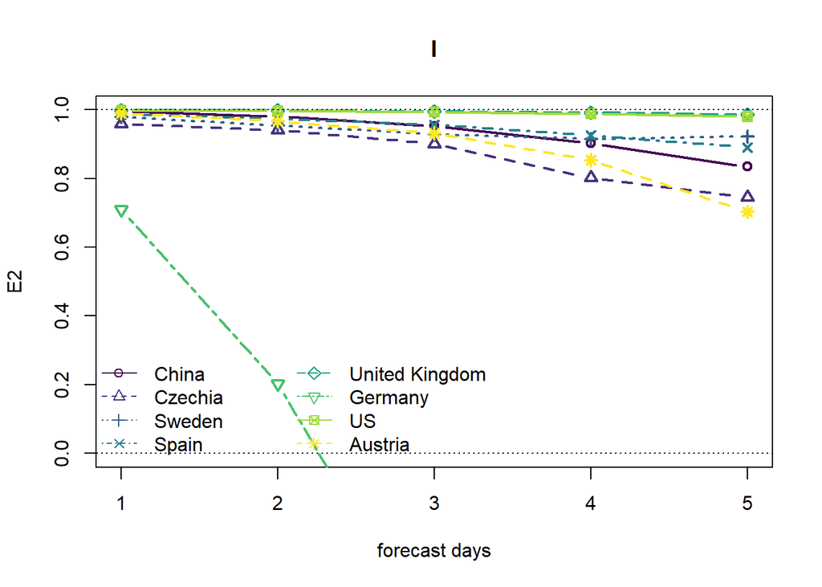

```r
require(viridis, quietly = TRUE)
collst<-viridis(ncountries)

# calculate goodness of fit for each lag and country
E2matI<-matrix(nrow=5, ncol=ncountries)
E2matR<-matrix(nrow=5, ncol=ncountries)
for(i in 1:ncountries) {
  for(j in 1:5) {
    obstmp<-Imat[-(1:j),i]
    predtmp<-Ipred[1:(nrow(Ipred)-j),i,j]
    ps<-is.finite(obstmp) & is.finite(predtmp)
    ps[-c((length(ps)-30):length(ps))]<-FALSE

    E2matI[j,i]<-1-mean((obstmp[ps]-predtmp[ps])^2, na.rm=T)/mean((obstmp[ps]-mean(obstmp[ps],na.rm=T))^2, na.rm=T)

    obstmp<-Rmat[-(1:j),i]
    predtmp<-Rpred[1:(nrow(Rpred)-j),i,j]
    ps<-is.finite(obstmp) & is.finite(predtmp)
    ps[-c((length(ps)-30):length(ps))]<-FALSE

    E2matR[j,i]<-1-mean((obstmp[ps]-predtmp[ps])^2, na.rm=T)/mean((obstmp[ps]-mean(obstmp[ps],na.rm=T))^2, na.rm=T)
  }
}

# plot output
# Infections
plot(c(1, 5), c(0, 1), xlab="forecast days", ylab="E2", type="n", main="I")
matlines(1:5, E2matI, col=collst, lty=1:ncountries, pch=1:ncountries, type="b", lwd=2)
abline(h=c(0,1), lty=3)

legend("bottomleft", countries$names, col=collst, lty=1:ncountries, bty="n", ncol=2, pch=1:ncountries)
```

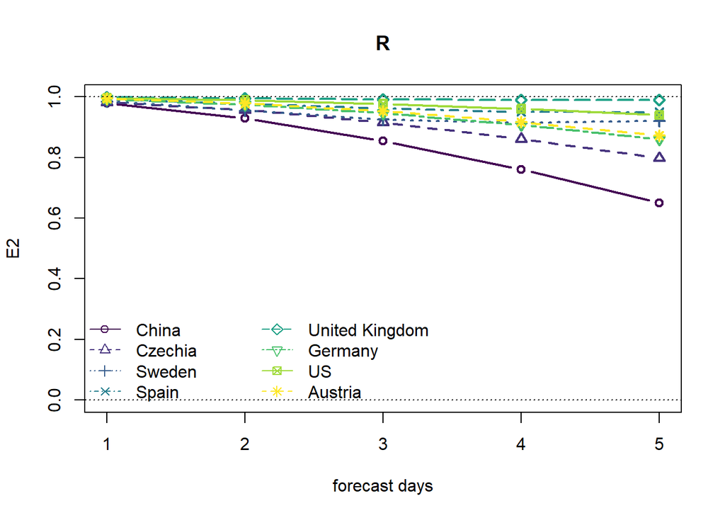

```r
# Recovered/removed
plot(c(1, 5), c(0, 1), xlab="forecast days", ylab="E2", type="n", main="R")
matlines(1:5, E2matR, col=collst, lty=1:ncountries, pch=1:ncountries, type="b", lwd=2)
abline(h=c(0,1), lty=3)

legend("bottomleft", countries$names, col=collst, lty=1:ncountries, bty="n", ncol=2, pch=1:ncountries)
```

Another way that we can visualize performance is to plot the actual time series. Below, the figures show the actual trends in black, and the estimates from various five-day forecasts in other colours. The vertical axis is for total confirmed cases - i.e. I+R. Note that the y-axis is shown in log space.

Note that in many cases, the five-day forecasts diverge greatly from observed dynamics (especially China in the first 30 days of the epidemic). When the predictions exceed observations, this indicates that infection rates slowed relative to historical behaviour. When predictions fall below observations, this indicates that infection rates increased relative to historical behaviour.

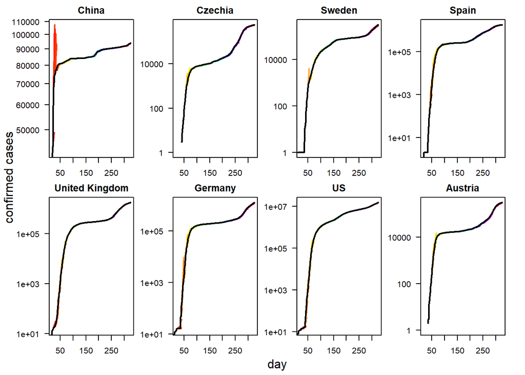

```r
startday<-20
predcols<-adjustcolor(rainbow(length(seq(startday, ndays, by=1))), alpha.f = 0.8)

par(mfrow=c(2,4), mar=c(2,2,2,2), oma=c(2,3,0,0))
for(i in 1:ncountries) {
  pltrng<-range(c(Imat[startday:ndays,i]+Rmat[startday:ndays,i], Ipred[startday:(ndays-5),i,]+Rpred[startday:(ndays-5),i,]), na.rm=T)
  pltrng[1]<-pmax(pltrng[1], 1)

  plot(c(1,ndays), c(1,1), xlim=c(startday, ndays), type="n", ylim=pltrng, main=countries$names[i], log="y", xlab="", ylab="", axes=FALSE)
  axis(1); axis(2, las=2); box()
  n<-1
  for(j in seq(startday, ndays, by=1)) {
    obstmpI<-Imat[j,i]
    predtmpI<-Ipred[j,i,]
    obstmpR<-Rmat[j,i]
    predtmpR<-Rpred[j,i,]
    ytmp<-c(obstmpI+obstmpR, predtmpI+predtmpR)
    xtmp<-(j+(0:5))

    lines(xtmp[xtmp<=ndays], ytmp[xtmp<=ndays], col=predcols[n], lwd=2)

    ps<-is.finite(obstmp) & is.finite(predtmp)
    n<-n+1
  }
  lines(1:ndays, Imat[,i]+Rmat[,i], col=1, lwd=2)
}

mtext("day", 1, outer=T, line=0.5)
mtext("confirmed cases", 2, outer=T, line=1.5)
```

## Rate estimates

We can also look at estimates of the rates $c$, $m$, and total per-capita growth of confirmed cases.

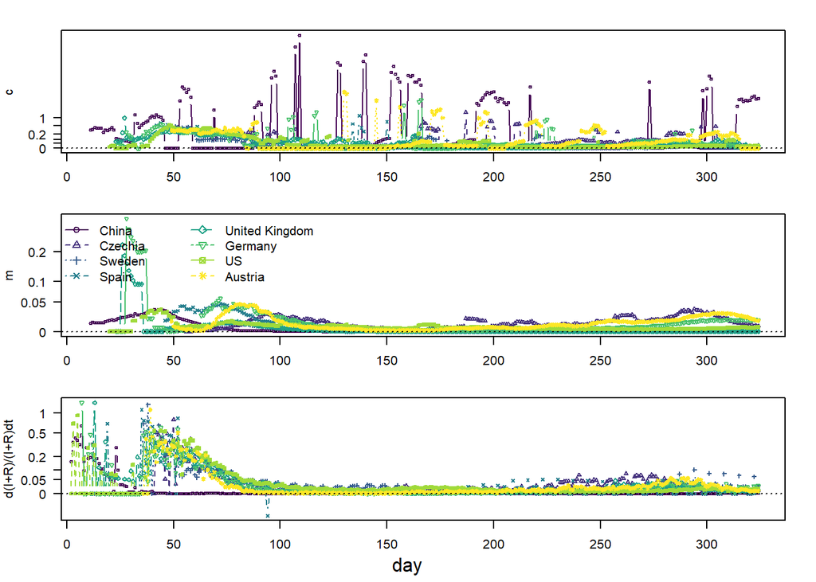

```r
lowerlim = 10

par(mfrow=c(3,1), mar=c(2,4,2,2), oma=c(2,0,0,0))
# c
cmat<-beta0mat+mmat
#use 0.1 as a lower cut-off for zero in log-space
matplot(1:ndays, log(cmat+0.1), col=collst, type="b", pch=1:ncountries, ylab="c", xlab="days", axes=FALSE, xlim=c(lowerlim,ndays), cex=0.5)
axis(1)
#adjust axis for cutoff
axissq<-c(0, 0.05, 0.1, 0.2, 0.5, 1)
axis(2, at=log(axissq+0.1), axissq, las=2); box()
abline(h=log(0.1), lty=3)

# m
#same axis scheme as above
matplot(1:ndays, log(mmat+0.1), col=collst, type="b", pch=1:ncountries, ylab="m", xlab="days", axes=FALSE, xlim=c(lowerlim,ndays), cex=0.5)
axis(1)
#adjust axis for cutoff
axissq<-c(0, 0.05, 0.1, 0.2, 0.5, 1, 2, 5, 10)
axis(2, at=log(axissq+0.1), axissq, las=2); box()
abline(h=log(0.1), lty=3)

legend("topleft", countries$names, col=collst, lty=1:ncountries, bty="n", ncol=2, pch=1:ncountries)

#total rate
matplot(1:ndays, log(dIpRIpRdt+0.1), col=collst, type="b", pch=1:ncountries, ylab="d(I+R)/(I+R)dt", xlab="days", axes=FALSE, xlim=c(lowerlim,ndays), cex=0.5)
axis(1)
#adjust axis for cutoff
axissq<-c(0, 0.05, 0.1, 0.2, 0.5, 1, 2, 5, 10)
axis(2, at=log(axissq+0.1), axissq, las=2); box()
abline(h=log(0.1), lty=3)

mtext("day", 1, outer=TRUE, line = 0.5)
```

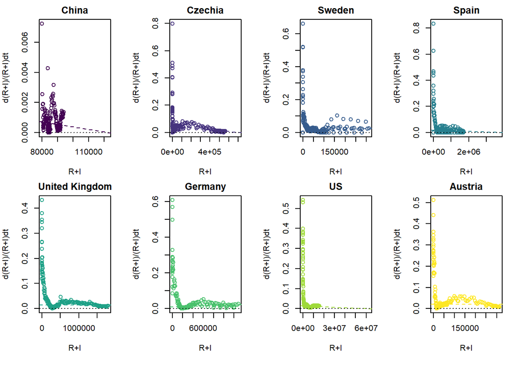

```r
par(mfrow=c(2,4), mar=c(4,4,2,2), oma=c(2,0,0,0))
for(i in 1:ncol(dIpRIpRdt)) {
  xdat<-(Imat+Rmat)[40:nrow(dIpRIpRdt),i]
  ydat<-dIpRIpRdt[40:nrow(dIpRIpRdt),i]



  mod<-step(lm(ydat~xdat, weights = xdat/sum(xdat, na.rm=T)), trace = FALSE)
  xlmuse<-c(min(xdat, na.rm=T), max(xdat, na.rm=T))

  if(length(coef(mod))==2 && coef(mod)[2]<0) {
    xlmuse[2]<-pmax(xlmuse[2], -coef(mod)[1]/coef(mod)[2])
  }

  plot(xdat, ydat, col=collst[i],
       ylim=c(0, max(ydat,na.rm=T)), xlim=xlmuse,
       xlab="R+I", ylab="d(R+I)/(R+I)dt",
       main=countries$names[i])
  abline(mod, lty=2, col=collst[i])
  abline(h=0, lty=3)
}
```

For some countries, it’s starting to look like we might be able to project dynamics forward towards potential saturation points (i.e. where the per-capita growth rate reaches zero). Again, recall that these projections are contingent on future behavior continuing to follow past trends, and only applies to changes in confirmed cases, not actual incidence.

## Latest forecasts

Finally, below are forecasts for the next five days, based on historical behaviour. The coloured lines show total number of cases for each country (i.e. I+R), whereas the grey dashed lines show number people who have recovered or died (i.e. R).

Again, please remember the caveats listed above. Additionally, be careful to compare these estimates to the goodness-of-fit reports above. In cases where past forecasts have done a poor job of predicting dynamics, it is unlikely that the current estimates are any good either.

Recall that data are always one day behind - so, day “zero” is for the observation from yesterday, and day “one” is the forecast for the end of today.

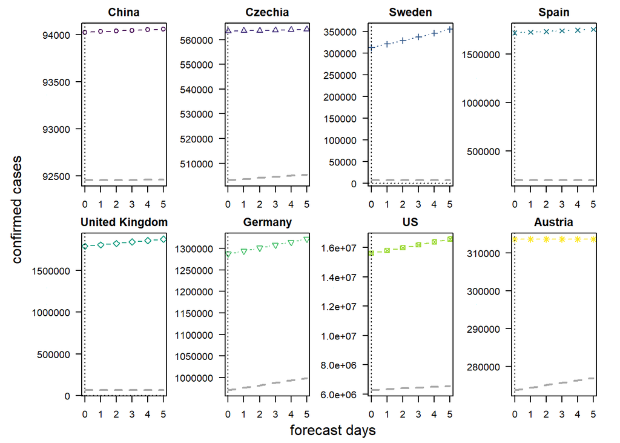

```r
par(mfrow=c(2,4), mar=c(2,3,2,2), oma=c(2,4,0,0))

#make sure that there aren't na's in the days we are trying to plot
ndaysplot<-ndays
mchange<-0
while(is.na(sum(c(Imat[ndaysplot,], Rmat[ndaysplot,])))) {
  ndaysplot<-ndaysplot-1
  mchange<-mchange+1
}

for(i in 1:ncountries) {
  plotdattmp<-c(Imat[ndaysplot,i]+Rmat[ndaysplot,i], Ipred[ndaysplot,i,]+Rpred[ndaysplot,i,])
  rng<-range(c(plotdattmp, c(Rmat[ndaysplot,i], Rpred[ndaysplot,i,])), na.rm=T)
  rng[1]<-pmax(1, rng[1])
  #rng[1]<-1

  plot(0:5-mchange, plotdattmp,
       type="b", col=collst[i], pch=i, lty=i,
       ylim=rng,
       xlab="forecast days", ylab="number of people",
       main=countries$names[i], log="", axes=F)
  lines(0:5-mchange, c(Rmat[ndaysplot,i], Rpred[ndaysplot,i,]), col="darkgrey", lty=2, lwd=2)
  abline(h=0, v=0, lty=3)
  axis(1); axis(2, las=2); box()
}
mtext("forecast days", 1, outer=T, line=0.5)
mtext("confirmed cases", 2, outer=T, line=2)
```

```r
print(paste("date of day 0: ", gsub("X", "", date)))
```

```
## [1] "date of day 0:  12.10.20"
```